# Kỹ thuật lập trình Python

## Làm quen với Numpy

### Bài 1. Tính toán trên dãy số

#### 1. Tạo một dãy số a có N phần tử (N = 10)

```python
import numpy as np # Khai báo thư viện numpy

print("1. Tạo một dãy số a có N phần tử (N = 10)")
""" CÁC BẠN LÀM BÀI Ở ĐÂY """
N = 10
a = np.random.randint(10, 50, size=N)


print("Day so a: ", a)
```

```
1. Tạo một dãy số a có N phần tử (N = 10)
Day so a:  [35 11 47 39 37 43 18 13 48 24]
```

#### 2. Các thao tác trên dãy số a

(a) Bình phương các phần tử trong dãy số  
(b) Tìm số lượng các phần tử của dãy số  
(c) In ra giá trị lớn nhất, giá trị nhỏ nhất và giá trị trung bình  
(d) Tính phương sai của dãy số $\sigma^2 = \frac{\sum{\left(a_i - \mu\right)^2}}{N - 1}$ với $\mu = \frac{\sum{a_i}}{N}$ và độ lệch chuẩn $var = \sqrt{\sigma^2}$

```python
print("2. Các thao tác tính toán đơn giản với dãy số a")
""" CÁC BẠN LÀM BÀI Ở ĐÂY """
a2 = a ** 2
na = len(a)

print("a. Binh phuong a: ", a2)
print("\nb. Do dai a: ", na)

""" CÁC BẠN LÀM BÀI Ở ĐÂY """
v_max = np.max(a)
v_min = np.min(a)
v_avg = np.mean(a)

print(f'\nc. Gia tri lon nhat: [{v_max}], gia tri nho nhat: [{v_min}], gia tri trung binh [{v_avg}]')

""" CÁC BẠN LÀM BÀI Ở ĐÂY """
v_sigma2 = np.var(a, ddof=1)
v_var = np.sqrt(v_sigma2)

print(f'\nd. Phuong sai: [{v_sigma2: .2f}] va do lech chuan: [{v_var: .2f}]')
```

```
2. Các thao tác tính toán đơn giản với dãy số a
a. Binh phuong a:  [1225  121 2209 1521 1369 1849  324  169 2304  576]

b. Do dai a:  10

c. Gia tri lon nhat: [48], gia tri nho nhat: [11], gia tri trung binh [31.5]

d. Phuong sai: [ 193.83] va do lech chuan: [ 13.92]
```

#### 3. Toán tử trên hai dãy số

(a) Tạo dãy số x có 10 phần tử từ 1 đến 10 (dùng hàm np.arange)  
(b) Liệt kê và đếm số lượng phần tử chẵn và lẻ có trong dãy a và x  
(c) Tính khoảng cách giữa các phần tử ở vị trí lẻ của mảng a và x với $s = \sqrt{\sum{\left(a_i - x_i\right)^2}}$ với $i$ lẻ  
(d) Tìm khoảng cách nhỏ nhất giữa tập a và x. Ví dụ: min({1, 3, 5}, {2, 10, 8}} = 1

```python
print("3. Xử lý khác trên dãy số")
""" CÁC BẠN LÀM BÀI Ở ĐÂY """
# ...
x = np.arange(1, 11)
print(f'a. Day so x: {x}')
```

```
3. Xử lý khác trên dãy số
a. Day so x: [ 1  2  3  4  5  6  7  8  9 10]
```

```python
""" CÁC BẠN LÀM BÀI Ở ĐÂY """
# ...
a_la_chan = a % 2 == 0
a_chan = a[a_la_chan]
n_a_chan = np.sum(a_la_chan)

x_la_chan = x % 2 == 0
x_chan = x[x_la_chan]
n_x_chan = np.sum(x_la_chan)
print( "b. Cac phan tu chan trong day a, b: ")
print(f"+ Day a: {a}")
print(f"  - Loc chan: {a_la_chan}")
print(f"  - Day chua phan tu chan trong a: {a_chan}, so luong {n_a_chan} phan tu.")
print(f"+ Day x: {x}")
print(f"  - Loc chan: {x_la_chan}")
print(f"  - Day chua phan tu chan trong a: {x_chan}, so luong {n_x_chan} phan tu.")
```

```
b. Cac phan tu chan trong day a, b:
+ Day a: [35 11 47 39 37 43 18 13 48 24]
  - Loc chan: [False False False False False False  True False  True  True]
  - Day chua phan tu chan trong a: [18 48 24], so luong 3 phan tu.
+ Day x: [ 1  2  3  4  5  6  7  8  9 10]
  - Loc chan: [False  True False  True False  True False  True False  True]
  - Day chua phan tu chan trong a: [ 2  4  6  8 10], so luong 5 phan tu.
```

```python
""" CÁC BẠN LÀM BÀI Ở ĐÂY """
# ...
v_le = np.arange(1, 11, 2)  # Odd indices: 1,3,5,7,9 (0-based: indices 1,3,5,7,9)

a_le = a[v_le - 1]  # Adjust for 0-based indexing
x_le = x[v_le - 1]

hieu_le = a_le - x_le
kc_le = np.sqrt(np.sum(hieu_le ** 2))
print( "c.Tính hiệu các phần tử ở vị trí lẻ của mảng a và x: ")
print(f"+ Vi tri le trong a va x: {v_le}")
print(f"+ Day so a: {a} va cac so o vi tri le: {a_le}")
print(f"+ Day so x: {x} va cac so o vi tri le: {x_le}")
print(f"+ Hieu cua a va x o vi tri le: {hieu_le}")
print(f"+ Khoang cach cac phan tu cua a va x o vi tri le: {kc_le: .2f}")
```

```
c.Tính hiệu các phần tử ở vị trí lẻ của mảng a và x:
+ Vi tri le trong a va x: [1 3 5 7 9]
+ Day so a: [35 11 47 39 37 43 18 13 48 24] va cac so o vi tri le: [35 47 37 18 48]
+ Day so x: [ 1  2  3  4  5  6  7  8  9 10] va cac so o vi tri le: [1 3 5 7 9]
+ Hieu cua a va x o vi tri le: [34 44 32 11 39]
+ Khoang cach cac phan tu cua a va x o vi tri le:  75.88
```

```python
print("d. Tìm khoảng cách nhỏ nhất giữa tập a và x. Ví dụ: min({1, 3, 5}, {2, 10, 8}} = 1")
"""
Gợi ý: Áp dụng toán tử broatcasting
[[1],                    [[1, 1, 1],        [[2, 10, 8],    =   [[-1, -9, -7],
 [3],   - [2, 10, 8] =    [3, 3, 3],   -     [2, 10, 8],         [ 1, -7, -5],  --> np.min(np.abs(...)) = 1
 [5]]                     [5, 5, 5]]         [2, 10, 8]]         [ 3, -5, -3]]
"""
""" CÁC BẠN LÀM BÀI Ở ĐÂY """
# Tăng số chiều dùng tại vị trí chiều cuối dùng np.newaxis như sau: a[:, np.newaxis]
# ...
diff = a[:, np.newaxis] - x[np.newaxis, :]
v_min = np.min(np.abs(diff))
print(f"+ Day a: {a}")
print(f"+ Day x: {x}")
print(f"+ Khoang cach nho nhat: {v_min}")
```

```
d. Tìm khoảng cách nhỏ nhất giữa tập a và x. Ví dụ: min({1, 3, 5}, {2, 10, 8}} = 1
+ Day a: [35 11 47 39 37 43 18 13 48 24]
+ Day x: [ 1  2  3  4  5  6  7  8  9 10]
+ Khoang cach nho nhat: 1
```

#### 4. Sinh ngẫu nhiên dãy số

(a) Sinh ngẫu nhiên dãy số có 100 phần tử theo phân bố đều với giá trị trong đoạn [1, 10] và vẽ đồ thị tần số xuất hiện
(b) Sinh ngẫu nhiên N diem (x, y) với y là hàm phân phối chuẩn $N(\mu = 1, \sigma^2 = 1.0)$:
$$ y = f\left(x| \mu, \sigma\right) = \frac{1}{\sigma\sqrt{2\pi}}exp\left(-\frac{\left(x - \mu\right)^2}{2\sigma^2}\right) $$ nơi mà $x \in [\mu - 5\sigma, \mu + 5\sigma]$
(c) Sinh ngẫu nhiên dãy số có 100000 phần tử theo phân bố chuẩn $N(\mu = 1, \sigma^2 = 1.0)$ và vẽ đồ thị tần số xuất hiện

```
a. Sinh ngẫu nhiên theo phân bố đều
+ Gia tri: [ 1  2  3  4  5  6  7  8  9 10]
+ So lan xuat hien: [ 4  8 12 19  8  5 12 11  9 12]
+ Do thi ham so xuat hien
```

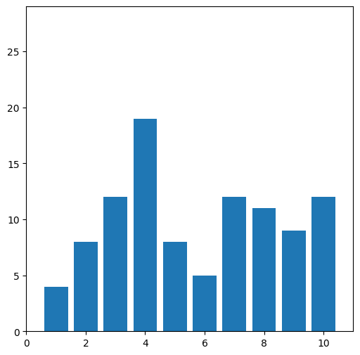

```python
import matplotlib.pyplot as plt  # Khai báo thư viện pyplot trong matplotlib

""" CÁC BẠN LÀM BÀI Ở ĐÂY """
# Sử dụng hàm np.random.randint để sinh dãy số ngẫu nhiên
# Sử dụng hàm np.unique để trả về tần số xuất hiện
# ...
import numpy as np

data = np.random.randint(1, 11, size=100)

value, cnt = np.unique(data, return_counts=True)

print("a. Sinh ngẫu nhiên theo phân bố đều")
print(f"+ Gia tri: {value}")
print(f"+ So lan xuat hien: {cnt}")
print("+ Do thi ham so xuat hien")
plt.figure(figsize=(6,6))      #  kich thuoc ban ve
plt.bar(value, cnt)            #  ve cac khoi chu nhat theo day x, y
plt.xlim(0, 11)                #  gioi han truc x
plt.ylim(0, np.max(cnt) + 10)  #  gioi han truc y
plt.savefig("4a.png")          #  luu do thi
plt.show()                     #  hien thi do thi
```

```
b. Sinh cặp (x, y) với y làm hàm phân phối chuẩn
+ x: -4.0 <= min [-3.97] <= max [ 6.00] <= 6.0
+ Ve ham so y(x)
```

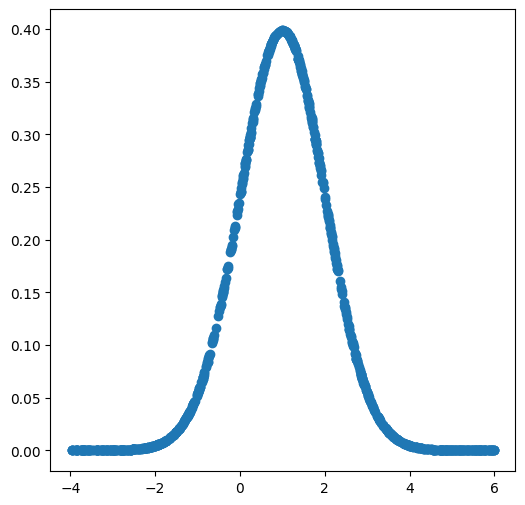

```python
""" CÁC BẠN LÀM BÀI Ở ĐÂY """
# Sử dụm hàm np.random.rand() sinh số ngẫu nhiên trong [0,1) --> [0,1) * (b - a) + a --> [a, b)
# Sử dụng hàm sau để tính hàm xác suất chuẩn N(m, s): np.sqrt, np.exp
# ...
mu = 1.0
sigma = 1.0
N = 1000  # Number of points
x_min = mu - 5 * sigma  # Lower bound: -4
x_max = mu + 5 * sigma  # Upper bound: 6

# Generate random x in [x_min, x_max) using np.random.rand
x = np.random.rand(N) * (x_max - x_min) + x_min  # Scale [0,1) to [-4,6)
# Compute y using normal PDF: f(x) = (1/(sigma*sqrt(2*pi))) * exp(-((x-mu)^2)/(2*sigma^2))
y = (1 / (sigma * np.sqrt(2 * np.pi))) * np.exp(-((x - mu)**2) / (2 * sigma**2))

print("b. Sinh cặp (x, y) với y làm hàm phân phối chuẩn")
print(f"+ x: {x_min} <= min [{np.min(x): .2f}] <= max [{np.max(x): .2f}] <= {x_max}")
print(f"+ Ve ham so y(x)")
plt.figure(figsize=(6,6))      # kich thuoc ban ve
plt.scatter(x, y)              # ve cac diem (xi, yi)
plt.savefig("4b.png")          #  luu do thi
plt.show()                     #  hien thi do thi
```

```
c. Sinh day so theo phan phoi chuan
+ x: len = 100000, min [-3.593081438149871], max [4.9247345811448255]
+ Mat so xac suat cua day so x
```

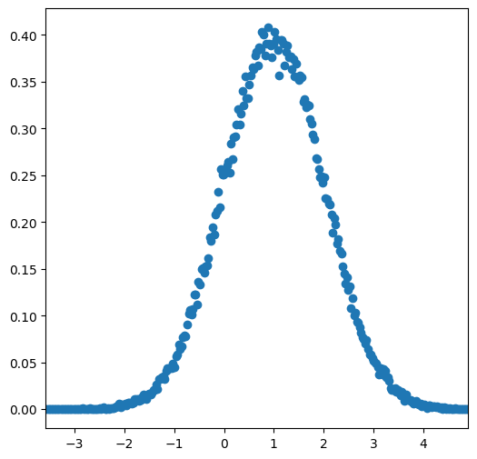

```python
""" CÁC BẠN LÀM BÀI Ở ĐÂY """
# Sử dụng hàm np.random.randn() sinh phân phối chuẩn N(0,1) --> N(m,s^2) = m + N(0,1) * s
# Sử dụng hàm np.histogram với density=True để thống kê số lần xuất hiện với số bins = 300 (do dãy số thực)
# ...

mu = 1.0
sigma = 1.0
n = 100000

# Generate normal distribution N(mu=1, sigma=1) using np.random.randn
x = mu + np.random.randn(n) * sigma  # N(mu, sigma^2) = mu + N(0,1) * sigma
# Compute histogram with density=True and bins=300
cnt, bins = np.histogram(x, bins=300, density=True)
# Compute bin centers for scatter plot (midpoints of bins)
val = (bins[:-1] + bins[1:]) / 2  # Centers of bins

print( "c. Sinh day so theo phan phoi chuan")
print(f"+ x: len = {len(x)}, min [{np.min(x)}], max [{np.max(x)}]")
print(f"+ Mat so xac suat cua day so x")
plt.figure(figsize=(6,6))      # kich thuoc ban ve
plt.xlim(np.min(val), np.max(val))
plt.scatter(val, cnt)
plt.show()
```

### Bài 2. Tính toán trên ma trận

#### 1. Tạo ma trận a có M = 6 dòng, N = 4 cột

```python
# a = np.random.randint(100, 200, (6, 4))
""" CÁC BẠN LÀM BÀI Ở ĐÂY """
# ...
a = np.random.randint(100, 200, (6, 4))
print("Ma trận a: \n", a)
```

```
Ma trận a:
 [[175 170 146 189]
 [129 129 178 158]
 [121 104 165 120]
 [120 101 136 169]
 [127 181 121 130]
 [191 159 187 108]]
```

#### 2. Các thao tác trên ma trận a

(a) In ra ma trận chuyển vị  
(b) In ra phần tử ở vị trí dòng 2 cột 3  
(c) Trích xuất dòng đầu, dòng cuối, dòng 2  
(d) Trích xuất cột kế cuối, cột đầu  
(e) Đảo các giá trị trên từng cột  
(f) Tính tổng các dòng, trung bình các cột

```python
""" CÁC BẠN LÀM BÀI Ở ĐÂY """
# ...
# Create 6x4 matrix with random integers in [100, 200)
a = np.random.randint(100, 200, (6, 4))
print("Ma trận a:\n", a)

# a. Transpose
a_t = a.T  # Shape: (4, 6)

# b. Element at row 2, column 3 (0-based indexing: row 1, column 2)
v_23 = a[1, 2]

# c. Extract rows
d_0 = a[0, :]    # First row
d_last = a[-1, :]  # Last row
d_2 = a[1, :]    # Second row

# d. Extract columns
c_l1 = a[:, -2]  # Second-to-last column
c_0 = a[:, 0]    # First column

# e. Reverse values in each column
dao_cot = a[::-1, :]  # Reverse row order

# f. Computations along axes
tong_dong = np.sum(a, axis=1)  # Sum of each row
tb_cot = np.mean(a, axis=0)    # Mean of each column

print(f"a. In ra ma trận chuyển vị: \n{a_t}")
print(f"\nb. In ra phần tử ở vị trí dòng 2 cột 3: {v_23}")
print(f"\nc. Trích xuất các dòng: ")
print(f"   + Dòng đầu : {d_0}")
print(f"   + Dòng cuối: {d_last}")
print(f"   + Dòng hai : {d_2}")
print(f"\nd. Trích xuất các cột: ")
print(f"   + Cột kế cuối: {c_l1}")
print(f"   + Cột đầu: {c_0}")
print(f"\ne. Đảo các giá trị trên từng cột: \n {dao_cot}")
print(f"\nf. Phép tính theo trục:")
print(f"   + Tổng dòng: {tong_dong}")
print(f"   + Trung bình cột: {tb_cot}")
```

```
Ma trận a:
 [[117 120 173 193]
 [128 156 123 124]
 [162 116 106 167]
 [197 186 157 153]
 [178 139 107 196]
 [169 118 128 144]]
a. In ra ma trận chuyển vị:
[[117 128 162 197 178 169]
 [120 156 116 186 139 118]
 [173 123 106 157 107 128]
 [193 124 167 153 196 144]]

b. In ra phần tử ở vị trí dòng 2 cột 3: 123

c. Trích xuất các dòng:
   + Dòng đầu : [117 120 173 193]
   + Dòng cuối: [169 118 128 144]
   + Dòng hai : [128 156 123 124]

d. Trích xuất các cột:
   + Cột kế cuối: [173 123 106 157 107 128]
   + Cột đầu: [117 128 162 197 178 169]

e. Đảo các giá trị trên từng cột:
 [[169 118 128 144]
 [178 139 107 196]
 [197 186 157 153]
 [162 116 106 167]
 [128 156 123 124]
 [117 120 173 193]]

f. Phép tính theo trục:
   + Tổng dòng: [603 531 551 693 620 559]
   + Trung bình cột: [158.5        139.16666667 132.33333333 162.83333333]
```

#### 3. Các toán tử trên hai ma trận

(a) Tạo hai ma trận A và B có 4 dòng x 3 cột và X có 3 dòng x 4 cột  
(b) Tính tổng, hiệu, tích của từng phần tử trên hai ma trận A và B  
(c) Tính phép nhân ma trận Y = A x X

```python
""" CÁC BẠN LÀM BÀI Ở ĐÂY """
# ...

# Create matrices with random integers in [1, 10]
A = np.random.randint(1, 11, size=(4, 3))  # 4x3 matrix
B = np.random.randint(1, 11, size=(4, 3))  # 4x3 matrix
X = np.random.randint(1, 11, size=(3, 4))  # 3x4 matrix

# b. Element-wise operations
AB_add = A + B  # Element-wise sum
AB_sub = A - B  # Element-wise difference
AB_mul = A * B  # Element-wise product

# c. Matrix multiplication Y = A x X
Y = A @ X  # 4x3 x 3x4 = 4x4

print("a. Tạo hai ma trận A và B có 4 dòng x 3 cột và X có 3 dòng x 4 cột")
print(f"+ Ma tran A: \n{A}")
print(f"+ Ma tran B: \n{B}")
print(f"+ Ma tran X: \n{X}")

print("\nb. Tính tổng, hiệu, tích của từng phần tử trên hai ma trận A và B")
print(f"A + B = \n{AB_add}")
print(f"A - B = \n{AB_sub}")
print(f"A . B = \n{AB_mul}")

print("\nc. Tính phép nhân ma trận Y = A x X")
print(f"Y = A x X --> shape A ({A.shape}) x shape X ({X.shape}) = shape Y ({Y.shape}) \n{Y}")
```

```
a. Tạo hai ma trận A và B có 4 dòng x 3 cột và X có 3 dòng x 4 cột
+ Ma tran A:
[[ 3  7  6]
 [10  7  6]
 [10  9  5]
 [ 3  4  7]]
+ Ma tran B:
[[ 1  5  9]
 [ 3  1  6]
 [ 1  6  8]
 [ 4 10  9]]
+ Ma tran X:
[[ 4  5  4  1]
 [ 3  1  8  2]
 [10  4  2 10]]

b. Tính tổng, hiệu, tích của từng phần tử trên hai ma trận A và B
A + B =
[[ 4 12 15]
 [13  8 12]
 [11 15 13]
 [ 7 14 16]]
A - B =
[[ 2  2 -3]
 [ 7  6  0]
 [ 9  3 -3]
 [-1 -6 -2]]
A . B =
[[ 3 35 54]
 [30  7 36]
 [10 54 40]
 [12 40 63]]

c. Tính phép nhân ma trận Y = A x X
Y = A x X --> shape A ((4, 3)) x shape X ((3, 4)) = shape Y ((4, 4))
[[ 93  46  80  77]
 [121  81 108  84]
 [117  79 122  78]
 [ 94  47  58  81]]
```

#### 4. Giải hệ phương trình tuyến tính

```python
""" CÁC BẠN LÀM BÀI Ở ĐÂY """
# ...
# Create 4x3 matrix A and 4x1 vector y with random integers in [1, 10]
A = np.random.randint(1, 11, size=(4, 3))
y = np.random.randint(1, 11, size=(4,))

# Solve Ax = y using pseudo-inverse
A_pinv = np.linalg.pinv(A)  # Pseudo-inverse of 4x3 matrix (results in 3x4)
x = A_pinv @ y  # Solution: x = A^+ * y (3x1)

# Compute yy = Ax for verification
yy = A @ x  # 4x3 x 3x1 = 4x1

# Compute L2 norm of the difference ||yy - y||_2
diff = np.linalg.norm(yy - y)

print(f"+ Ma tran A: \n{A}")
print(f"+ Vector y: {y}")
print(f"+ Nghiem x: {x}")
print(f"+ Kiem tra: yy = Ax = {yy} ==> ||yy -y ||_2 = {diff: .2f}")
```

```
+ Ma tran A:
[[3 4 5]
 [8 5 8]
 [4 4 1]
 [7 1 1]]
+ Vector y: [5 8 5 9]
+ Nghiem x: [ 1.17348501  0.24677313 -0.20498797]
+ Kiem tra: yy = Ax = [3.48260774 8.98184205 5.47604463 8.25618027] ==> ||yy -y ||_2 =  2.01
```

## Bài tập áp dụng

### Bài 3. Tính gần đúng số pi dùng phương pháp Monte Carlo

Vẽ một đường tròn $C$ có bán kính $r$ nội tiếp một hình vuông $C$, và đặt ngẫu nhiên $N$ chấm lên hình vuông. Tỉ lệ các chấm nằm trong hình tròn trên tổng số chấm xấp xỉ bằng diện tích của hình tròn chia cho hình vuông như sau: $$ \frac{N_C}{N} \approx \frac{\mathbb{S}_C}{\mathbb{S}_N} $$ nơi mà $N_C$ là các chấm trong hình tròn, $N$ là tổng số chấm, $\mathbb{S}_C$ và $\mathbb{S}_N$ lần lượt là diện tích của hình tròn và hình vuông. $$ \mathbb{S}_C = \pi * r^2 $$ $$ \mathbb{S}_N = (2*r)^2 = 4r^2 $$ Do đó, công thức trên trở thành: $$ \frac{N_C}{N} \approx \frac{\pi * r^2}{4r^2} = \frac{\pi}{4} $$ Suy ra, ta có giá trị số $\pi$ được tính như sau: $$ \pi \approx \frac{4N_C}{N} $$

Các bạn hãy lập trình tính sấp xỉ số $\pi$ dùng phương pháp Monte Carlo. Cho biết các sai số với $N = 100$, $N = 10000$, và $N = 1000000$. Vẽ đồ thị minh họa cho chương trình.

**Hướng dẫn**: Viết chương trình phát sinh $N$ điểm $(x_i, y_i)$ với $x_i, y_i \in [-1, -1]$. $(x_i, y_i)$ thuộc hình tròn tâm $(0, 0)$ bán kính 1 nội tiếp hình vuông có tâm tại $(0, 0)$ độ dài cạnh 2 khi và chỉ khi $x_i^2 + y_i^2 <= 1$.

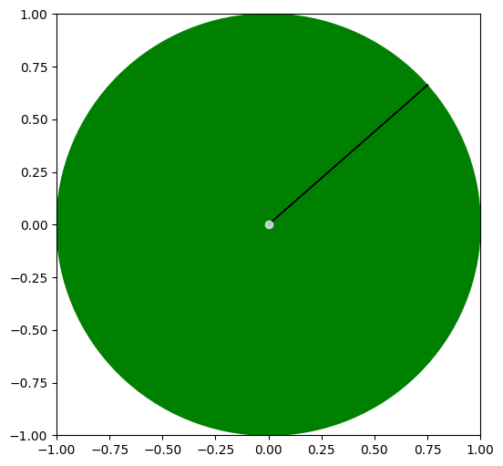

```python
import matplotlib.pyplot as plt # khai báo thư viện vẽ pyplot
import math

circle = plt.Circle((0, 0), 1, color='g') # tạo đối tượng vòng tròn

fig, ax = plt.subplots(figsize=(6, 6)) # lấy figure và vùng vẽ

plt.plot(0, 0, 'o', color=(0.9, 0.9, 1.0), alpha=0.8) # vẽ điểm tại tâm (0,0)
ax.add_patch(circle) # thêm vòng tròn vào vùng vẽ

x = 0.75; y = math.sqrt(1 - (x ** 2)) # (x = 0.75, y = căn bậc 2 của 1 - x^2)
plt.arrow(0, 0, x, y)

plt.xlim(-1, 1) # giới hạn trục x
plt.ylim(-1, 1) # giới hạn trục y

plt.savefig('pi.png') # lưu đồ thị xuống tập tin
plt.show()            # hiển thị đồ thị
```

```python
import numpy as np

def calc_pi_monte_carlo(n = 100):
    pi = 0

    # gợi ý: sử dụng np.random.rand(s1, s2, ...) --> sinh ngẫu nhiên các số trong nửa đoạn [0.0, 1.0)
    """ CÁC BẠN LÀM BÀI Ở ĐÂY """
    # ...
     # Generate N random points in [0, 1) x [0, 1)
    x = np.random.rand(n)
    y = np.random.rand(n)

    # Scale to [-1, 1) x [-1, 1)
    x = x * 2 - 1  # [0, 1) -> [0, 2) -> [-1, 1)
    y = y * 2 - 1

    # Count points inside the unit circle (x^2 + y^2 <= 1)
    inside = np.sum(x**2 + y**2 <= 1)

    # Estimate pi: 4 * (points inside / total points)
    pi = 4 * inside / n
    return pi
# calc_pi_monte_carlo
```

```python
import math

print("epsilon(n=100): ", calc_pi_monte_carlo(n = 100) - math.pi)
print("epsilon(n=100): ", calc_pi_monte_carlo(n = 100) - math.pi)
print("epsilon(n=10000): ", calc_pi_monte_carlo(n = 10000) - math.pi)
print("epsilon(n=10000): ", calc_pi_monte_carlo(n = 10000) - math.pi)
print("epsilon(n=1000000): ", calc_pi_monte_carlo(n = 1000000) - math.pi)
print("epsilon(n=1000000): ", calc_pi_monte_carlo(n = 1000000) - math.pi)
```

```
epsilon(n=100):  -0.2215926535897932
epsilon(n=100):  -0.14159265358979312
epsilon(n=10000):  -0.007192653589793263
epsilon(n=10000):  -0.023592653589793233
epsilon(n=1000000):  0.0007713464102070411
epsilon(n=1000000):  0.0029513464102066678
```